# Regression Project

Team 2 (김주우 김하균 박경민 이지은)

2019년 1월 31일

# **주제**

기후와 경제를 이용한 미세먼지 예측

## **목차**

1. 데이터 셋 만들기
2. EDA
3. 회귀분석

### **1. 데이터 셋 만들기**

#### **i) 데이터 수집**

| 사용데이터 | 데이터 수집 사이트 | 사이트 링크 |
| --- | --- | --- |
| 미세먼지 | 에어코리아 | http://www.airkorea.or.kr/web/last_amb_hour_data?pMENU_NO=123 |
| 기후 | 기상청 기상자료개방포털 | https://data.kma.go.kr/data/grnd/selectAsosRltmList.do?pgmNo=36 |
| 코스피 지수 | 네이버 증권 크롤링 | https://finance.naver.com/sise/sise_index.nhn?code=KOSPI |
| 석유 소비량 | 서울 열린 데이터 광장 | http://data.seoul.go.kr/dataList/datasetView.do?infId=128&srvType=S&serviceKind=2 |
| 경유 소비량 | 한국 석유 공사 | http://www.petronet.co.kr/main2.jsp |

각각 서울시 내의 25개의 구에 관한 데이터들을 수집.

#### **ii) 데이터 변환**

2010년 ~ 2017년까지의 데이터를 수집하여 서울시 25개의 구와 날짜(일)를 기준으로 잡고 데이터를 변환

```r
library(tidyverse)

setwd("C:/FastCampus/Regression Project/")
```

##### A. 미세먼지

구별/시간별 데이터를 수집

```r
load(file = "data/PM.RData")

head(PM)
```

```
## # A tibble: 6 x 10
##   location  year month   day  hour   SO2    CO    O3   NO2  PM10
##   <fct>    <dbl> <dbl> <dbl> <dbl> <dbl> <dbl> <dbl> <dbl> <dbl>
## 1 강남구    2010     1     1     1 0.005   0.4 0.011 0.027    30
## 2 강남구    2010     1     1     2 0.005   0.5 0.006 0.034    35
## 3 강남구    2010     1     1     3 0.005   0.5 0.008 0.03     36
## 4 강남구    2010     1     1     4 0.005   0.5 0.008 0.03     31
## 5 강남구    2010     1     1     5 0.005   0.4 0.009 0.027    33
## 6 강남구    2010     1     1     6 0.006   0.4 0.008 0.03     36
```

구별/일별 데이터로 변환

```r
# loc <- levels(PM$location)
# location <- c()
# year <- c()
# month <- c()
# day <- c()
# SO2 <- c()
# CO <- c()
# O3 <- c()
# NO2 <- c()
# PM10 <- c()
# for(a in loc){
#   for(b in 2010:2017){
#     for(c in 1:12){
#       if(b %in% c(2012, 2016)){
#         if(c %in% c(1, 3, 5, 7, 8, 10, 12)){
#           day.date <- 31
#         } else if(c == 2){
#           day.date <- 29
#         } else {
#           day.date <- 30
#         }
#       } else {
#         if(c %in% c(1, 3, 5, 7, 8, 10, 12)){
#           day.date <- 31
#         } else if(c == 2){
#           day.date <- 28
#         } else {
#           day.date <- 30
#         }
#       }
#       for(d in 1:day.date){
#         data <- PM %>%
#           dplyr::filter((location == a) & (year == b) & (month == c) & (day == d))
#         location <- c(location, levels(data$location)[1])
#         year <- c(year, data$year[1])
#         month <- c(month, data$month[1])
#         day <- c(day, data$day[1])
#         SO2 <- c(SO2, round(mean(data$SO2, na.rm = TRUE), digits = 3))
#         CO <- c(CO, round(mean(data$CO, na.rm = TRUE), digits = 1))
#         O3 <- c(O3, round(mean(data$O3, na.rm = TRUE), digits = 3))
#         NO2 <- c(NO2, round(mean(data$NO2, na.rm = TRUE), digits = 3))
#         PM10 <- c(PM10, round(mean(data$PM10, na.rm = TRUE), digits = 0))
#       }
#     }
#   }
# }
# location2 <- rep(loc, each = 2922)
# dailyPM <- data.frame(location2, year, month, day, SO2, CO, O3, NO2, PM10)
load(file = 'data/dailyPM.Rdata')
head(dailyPM)
```

```
##   location year month day   SO2  CO    O3   NO2 PM10
## 1   강남구 2010     1   1 0.006 0.6 0.007 0.037   36
## 2   강남구 2010     1   2 0.008 0.6 0.008 0.037   56
## 3   강남구 2010     1   3 0.007 0.7 0.012 0.041   50
## 4   강남구 2010     1   4 0.005 0.6 0.009 0.042   38
## 5   강남구 2010     1   5 0.006 0.5 0.017 0.032   50
## 6   강남구 2010     1   6 0.005 0.6 0.014 0.040   37
```

##### B. 기후

기상청 기상자료개방포털에서 시간별, 일별자료를 제공하는데 일별 데이터를 수집

```r
weather.data <- readxl::read_excel(path = "data/기후/기후통합.xlsx", sheet = 1, col_names = TRUE)
head(weather.data)
```

```
## # A tibble: 6 x 9
##    year month   day  temp  prec  cbwd    ws  humi  pres
##   <dbl> <dbl> <dbl> <dbl> <dbl> <dbl> <dbl> <dbl> <dbl>
## 1  2010     1     1  -7.6  NA      70   1.9  48   1011.
## 2  2010     1     2  -3.6   1.4   290   2.8  76.4 1006.
## 3  2010     1     3  -6.8  NA     290   2.2  49.3 1011.
## 4  2010     1     4  -5.9  14.2   320   3    84.1 1002.
## 5  2010     1     5  -9.9   0     290   2.9  66.4 1011.
## 6  2010     1     6 -11.2  NA     290   1.9  65.5 1014.
```

구별/일별 데이터로 변환

```r
weather.data$year <- NULL
weather.data$month <- NULL
weather.data$day <- NULL
weather <- rbind(weather.data, weather.data, weather.data, weather.data, weather.data,
                 weather.data, weather.data, weather.data, weather.data, weather.data,
                 weather.data, weather.data, weather.data, weather.data, weather.data,
                 weather.data, weather.data, weather.data, weather.data, weather.data,
                 weather.data, weather.data, weather.data, weather.data, weather.data)
PM <- cbind(dailyPM, weather)
head(PM)
```

```
##   location year month day   SO2  CO    O3   NO2 PM10  temp prec cbwd  ws
## 1   강남구 2010     1   1 0.006 0.6 0.007 0.037   36  -7.6   NA   70 1.9
## 2   강남구 2010     1   2 0.008 0.6 0.008 0.037   56  -3.6  1.4  290 2.8
## 3   강남구 2010     1   3 0.007 0.7 0.012 0.041   50  -6.8   NA  290 2.2
## 4   강남구 2010     1   4 0.005 0.6 0.009 0.042   38  -5.9 14.2  320 3.0
## 5   강남구 2010     1   5 0.006 0.5 0.017 0.032   50  -9.9  0.0  290 2.9
## 6   강남구 2010     1   6 0.005 0.6 0.014 0.040   37 -11.2   NA  290 1.9
##   humi   pres
## 1 48.0 1010.6
## 2 76.4 1006.2
## 3 49.3 1010.7
## 4 84.1 1002.4
## 5 66.4 1011.4
## 6 65.5 1014.4
```

##### C. 코스피

네이버 증권, 국내증시에서 아래의 일별 체결가를 찾은 후 크롤링

```r
library(httr)
library(rvest)
```

```r
result <- data.frame()
for(i in 1:380){
  res <- GET(url = 'https://finance.naver.com/sise/sise_index_day.nhn',
             query = list(code = 'KOSPI',
                          page = i))
  items <- res %>%
    read_html() %>%
    html_nodes(css = 'table.type_1') %>%
    html_table(fill = TRUE) %>%
    as.data.frame() %>%
    na.omit() %>%
    dplyr::select(1:2)
  result <- rbind(result, items)
}
head(result)
```

```
##          날짜   체결가
## 2  2019.01.31 2,204.85
## 3  2019.01.30 2,206.20
## 4  2019.01.29 2,183.36
## 9  2019.01.28 2,177.30
## 10 2019.01.25 2,177.73
## 11 2019.01.24 2,145.03
```

이 때 코스피에서 빠진 날짜가 많았기 때문에 모든 날짜를 포함한 데이터를 만들어 병합

```r
kospi.data <- readxl::read_excel(path = "data/kospi/kospi.xlsx", sheet = 1, col_names = TRUE)
head(kospi.data)
```

```
## # A tibble: 6 x 4
##    year month   day price
##   <dbl> <dbl> <dbl> <chr>
## 1  2010     1     4 1,696.14
## 2  2010     1     5 1,690.62
## 3  2010     1     6 1,705.32
## 4  2010     1     7 1,683.45
## 5  2010     1     8 1,695.26
## 6  2010     1    11 1,694.12
```

```r
comp <- readxl::read_excel(path = "data/kospi/comparison.xlsx", sheet = 1, col_names = TRUE)
head(comp)
```

```
## # A tibble: 6 x 3
##    year month   day
##   <dbl> <dbl> <dbl>
## 1  2010     1     1
## 2  2010     1     2
## 3  2010     1     3
## 4  2010     1     4
## 5  2010     1     5
## 6  2010     1     6
```

```r
kospi.result <- dplyr::left_join(comp, kospi.data, by = c("year", "month", "day"))
head(kospi.result)
```

```
## # A tibble: 6 x 4
##    year month   day price
##   <dbl> <dbl> <dbl> <chr>
## 1  2010     1     1 <NA>
## 2  2010     1     2 <NA>
## 3  2010     1     3 <NA>
## 4  2010     1     4 1,696.14
## 5  2010     1     5 1,690.62
## 6  2010     1     6 1,705.32
```

또한 코스피는 일별데이터로 만들었기 때문에 데이터를 중복하여 구별/일별데이터로 변환

```r
kospi <- rep(kospi.result$price, time = 25)
kospi <- kospi %>% gsub(pattern = ',', replacement = '') %>% as.numeric()
PM <- cbind(PM, kospi)
head(PM)
```

```
##   location year month day   SO2  CO    O3   NO2 PM10  temp prec cbwd  ws
## 1   강남구 2010     1   1 0.006 0.6 0.007 0.037   36  -7.6   NA   70 1.9
## 2   강남구 2010     1   2 0.008 0.6 0.008 0.037   56  -3.6  1.4  290 2.8
## 3   강남구 2010     1   3 0.007 0.7 0.012 0.041   50  -6.8   NA  290 2.2
## 4   강남구 2010     1   4 0.005 0.6 0.009 0.042   38  -5.9 14.2  320 3.0
## 5   강남구 2010     1   5 0.006 0.5 0.017 0.032   50  -9.9  0.0  290 2.9
## 6   강남구 2010     1   6 0.005 0.6 0.014 0.040   37 -11.2   NA  290 1.9
##   humi   pres   kospi
## 1 48.0 1010.6      NA
## 2 76.4 1006.2      NA
## 3 49.3 1010.7      NA
## 4 84.1 1002.4 1696.14
## 5 66.4 1011.4 1690.62
## 6 65.5 1014.4 1705.32
```

##### D. 석유 소비량

월별 데이터로 수집

```r
report <- readxl::read_excel(path = "data/경유/report.xlsx", sheet = 1, col_names = TRUE)

head(report)
```

```
## # A tibble: 6 x 6
##    year month 휘발유  등유 벙커C유   LPG
##   <dbl> <dbl>  <dbl> <dbl>   <dbl> <dbl>
## 1  2000     1   1030  1654     219   106
## 2  2000     2   1070  1519     216   784
## 3  2000     3   1142   870     159   883
## 4  2000     4   1108   500      89   882
## 5  2000     5   1264   342     103   894
## 6  2000     6   1053   140      55   851
```

데이터를 중복하여 구별/일별 데이터로 변환

```r
# colnames(report) <- c("year", "month", "gasoline", "kerosene", "bunker", "LPG")
# loc <- levels(dailyPM$location)
# gasoline <- c()
# kerosene <- c()
# bunker <- c()
# LPG <- c()
# for(a in loc){
#   for(b in 2010:2017){
#     for(c in 1:12){
#       if(b %in% c(2012, 2016)){
#         if(c %in% c(1, 3, 5, 7, 8, 10, 12)){
#           day.date <- 31
#         } else if(c == 2){
#           day.date <- 29
#         } else {
#           day.date <- 30
#         }
#       } else {
#         if(c %in% c(1, 3, 5, 7, 8, 10, 12)){
#           day.date <- 31
#         } else if(c == 2){
#           day.date <- 28
#         } else {
#           day.date <- 30
#         }
#       }
#       for(d in 1:day.date){
#         data <- report %>%
#           dplyr::filter((year == b) & (month == c))
#         gasoline <- c(gasoline, data$gasoline)
#         kerosene <- c(kerosene, data$kerosene)
#         bunker <- c(bunker, data$bunker)
#         LPG <- c(LPG, data$LPG)
#       }
#     }
#   }
# }
# report <- data.frame(gasoline, kerosene, bunker, LPG)
load(file = 'data/report.Rdata')
PM <- cbind(PM, report)
head(PM)
```

```
##   location year month day   SO2  CO    O3   NO2 PM10  temp prec cbwd  ws
## 1   강남구 2010     1   1 0.006 0.6 0.007 0.037   36  -7.6   NA   70 1.9
## 2   강남구 2010     1   2 0.008 0.6 0.008 0.037   56  -3.6  1.4  290 2.8
## 3   강남구 2010     1   3 0.007 0.7 0.012 0.041   50  -6.8   NA  290 2.2
## 4   강남구 2010     1   4 0.005 0.6 0.009 0.042   38  -5.9 14.2  320 3.0
## 5   강남구 2010     1   5 0.006 0.5 0.017 0.032   50  -9.9  0.0  290 2.9
## 6   강남구 2010     1   6 0.005 0.6 0.014 0.040   37 -11.2   NA  290 1.9
##   humi   pres   kospi gasoline kerosene bunker LPG
## 1 48.0 1010.6      NA      794      224     32 880
## 2 76.4 1006.2      NA      794      224     32 880
## 3 49.3 1010.7      NA      794      224     32 880
## 4 84.1 1002.4 1696.14      794      224     32 880
## 5 66.4 1011.4 1690.62      794      224     32 880
## 6 65.5 1014.4 1705.32      794      224     32 880
```

##### E. 경유 소비량

구별/월별 데이터로 수집

```r
oil.data <- readxl::read_excel(path = "data/경유/oil.xlsx", sheet = 1, col_names = TRUE)

head(oil.data)
```

```
## # A tibble: 6 x 27
##    year month 종로구  중구 동대문구 성동구 성북구 도봉구 서대문구 은평구
##   <dbl> <dbl>  <dbl> <dbl>    <dbl>  <dbl>  <dbl>  <dbl>    <dbl>  <dbl>
## 1  2010     1   1036  3370     4326   3498   4632   2338     1683   3418
## 2  2010     2   1549  3587     4377   3498   4469   2535     1785   3704
## 3  2010     3   1273  3208     4785   3765   4995   2759     2129   4425
## 4  2010     4   1404  3606     4699   3842   4541   2844     2151   4049
## 5  2010     5   1333  2814     4706   3605   4866   2831     2236   4269
## 6  2010     6   1311  3650     4285   3575   4881   2573     2196   3993
## # ... with 17 more variables: 마포구 <dbl>, 용산구 <dbl>, 영등포구 <dbl>,
## #   동작구 <dbl>, 강남구 <dbl>, 강동구 <dbl>, 강서구 <dbl>, 구로구 <dbl>,
## #   관악구 <dbl>, 노원구 <dbl>, 양천구 <dbl>, 중랑구 <dbl>, 서초구 <dbl>,
## #   송파구 <dbl>, 광진구 <dbl>, 강북구 <dbl>, 금천구 <dbl>
```

구별/일별 데이터로 변환

```r
# oil <- c()
# for(a in loc){
#   for(b in 2010:2017){
#     for(c in 1:12){
#       if(b %in% c(2012, 2016)){
#         if(c %in% c(1, 3, 5, 7, 8, 10, 12)){
#           day.date <- 31
#         } else if(c == 2){
#           day.date <- 29
#         } else {
#           day.date <- 30
#         }
#       } else {
#         if(c %in% c(1, 3, 5, 7, 8, 10, 12)){
#           day.date <- 31
#         } else if(c == 2){
#           day.date <- 28
#         } else {
#           day.date <- 30
#         }
#       }
#       for(d in 1:day.date){
#         data <- oil.data %>%
#           dplyr:filter((year == b) & (month == c)) %>%
#           dplyr::select(a)
#         oil <- c(oil, data)
#       }
#     }
#   }
# }
load(file = 'data/oil.Rdata')
PM <- cbind(PM, oil)
head(PM)
```

```
##   location year month day   SO2  CO    O3   NO2 PM10  temp prec cbwd  ws
## 1   강남구 2010     1   1 0.006 0.6 0.007 0.037   36  -7.6   NA   70 1.9
## 2   강남구 2010     1   2 0.008 0.6 0.008 0.037   56  -3.6  1.4  290 2.8
## 3   강남구 2010     1   3 0.007 0.7 0.012 0.041   50  -6.8   NA  290 2.2
## 4   강남구 2010     1   4 0.005 0.6 0.009 0.042   38  -5.9 14.2  320 3.0
## 5   강남구 2010     1   5 0.006 0.5 0.017 0.032   50  -9.9  0.0  290 2.9
## 6   강남구 2010     1   6 0.005 0.6 0.014 0.040   37 -11.2   NA  290 1.9
##   humi   pres   kospi gasoline kerosene bunker LPG  oil
## 1 48.0 1010.6      NA      794      224     32 880 7452
## 2 76.4 1006.2      NA      794      224     32 880 7452
## 3 49.3 1010.7      NA      794      224     32 880 7452
## 4 84.1 1002.4 1696.14      794      224     32 880 7452
## 5 66.4 1011.4 1690.62      794      224     32 880 7452
## 6 65.5 1014.4 1705.32      794      224     32 880 7452
```

##### iii) 데이터 변수 설명

| 변수명 | 변수 설명 | 단위 |
| --- | --- | --- |
| SO2 | 대기오염물질, 아황산가스의 공기 중 농도 | ppm |
| CO | 대기오염물질, 일산화탄소의 공기 중 농도 | ppm |
| O3 | 대기오염물질, 오존의 공기 중 농도 | ppm |
| NO2 | 대기오염물질, 이산화질소의 공기 중 농도 | ppm |
| PM10 | 1000분의 10mm보다 작은 먼지의 공기 중 농도 | microgram/cubicmeter |
| temp | 기온 | ℃ |
| prec | 강수량 | mm |
| cbwd | 풍향 | Deg |
| ws | 풍속 | m/s |
| humi | 상대습도 | % |
| pres | 기압 | hPa |
| oil | 경유 | KL |
| gasoline | 휘발유 | 천배럴, 1000bbl |
| kerosene | 등유 | 천배럴, 1000bbl |
| bunker | 벙커C유 | 천배럴, 1000bbl |
| LPG | LPG | 천배럴, 1000bbl |
| kospi | 국내증시 코스피지수 체결가 |  |

### **2. EDA**

#### **i) 자료분석**

```r
str(PM)
```

```
## 'data.frame':    73050 obs. of  21 variables:
##  $ location: Factor w/ 25 levels "강남구","강동구",..: 1 1 1 1 1 1 1 1 1 1 ...
##  $ year    : num  2010 2010 2010 2010 2010 2010 2010 2010 2010 2010 ...
##  $ month   : num  1 1 1 1 1 1 1 1 1 1 ...
##  $ day     : num  1 2 3 4 5 6 7 8 9 10 ...
##  $ SO2     : num  0.006 0.008 0.007 0.005 0.006 0.005 0.006 0.007 0.007 0.008 ...
##  $ CO      : num  0.6 0.6 0.7 0.6 0.5 0.6 0.9 1.2 1.2 1 ...
##  $ O3      : num  0.007 0.008 0.012 0.009 0.017 0.014 0.006 0.004 0.003 0.004 ...
##  $ NO2     : num  0.037 0.037 0.041 0.042 0.032 0.04 0.06 0.074 0.078 0.066 ...
##  $ PM10    : num  36 56 50 38 50 37 65 87 93 72 ...
##  $ temp    : num  -7.6 -3.6 -6.8 -5.9 -9.9 -11.2 -10.1 -8 -5.1 -3.4 ...
##  $ prec    : num  NA 1.4 NA 14.2 0 NA NA NA 0.4 NA ...
##  $ cbwd    : num  70 290 290 320 290 290 270 290 70 290 ...
##  $ ws      : num  1.9 2.8 2.2 3 2.9 1.9 1.7 1.7 1.5 1.7 ...
##  $ humi    : num  48 76.4 49.3 84.1 66.4 65.5 66.8 67.4 75.8 79.1 ...
##  $ pres    : num  1011 1006 1011 1002 1011 ...
##  $ kospi   : num  NA NA NA 1696 1691 ...
##  $ gasoline: num  794 794 794 794 794 794 794 794 794 794 ...
##  $ kerosene: num  224 224 224 224 224 224 224 224 224 224 ...
##  $ bunker  : num  32 32 32 32 32 32 32 32 32 32 ...
##  $ LPG     : num  880 880 880 880 880 880 880 880 880 880 ...
##  $ oil     : num  7452 7452 7452 7452 7452 ...
```

```r
summary(PM)
```

```
##     location          year          month             day
##  강남구 : 2922   Min.   :2010   Min.   : 1.000   Min.   : 1.00
##  강동구 : 2922   1st Qu.:2012   1st Qu.: 4.000   1st Qu.: 8.00
##  강북구 : 2922   Median :2014   Median : 7.000   Median :16.00
##  강서구 : 2922   Mean   :2014   Mean   : 6.523   Mean   :15.73
##  관악구 : 2922   3rd Qu.:2016   3rd Qu.:10.000   3rd Qu.:23.00
##  광진구 : 2922   Max.   :2017   Max.   :12.000   Max.   :31.00
##  (Other):55518
##       SO2               CO               O3             NO2
##  Min.   :0.0000   Min.   :0.1000   Min.   :0.000   Min.   :0.0010
##  1st Qu.:0.0040   1st Qu.:0.4000   1st Qu.:0.012   1st Qu.:0.0220
##  Median :0.0050   Median :0.5000   Median :0.020   Median :0.0300
##  Mean   :0.0052   Mean   :0.5304   Mean   :0.022   Mean   :0.0321
##  3rd Qu.:0.0060   3rd Qu.:0.6000   3rd Qu.:0.030   3rd Qu.:0.0400
##  Max.   :0.0320   Max.   :2.8000   Max.   :0.093   Max.   :0.1110
##  NA's   :640      NA's   :702      NA's   :727     NA's   :601
##       PM10             temp             prec             cbwd
##  Min.   :  3.00   Min.   :-14.50   Min.   :  0.00   Min.   : 20
##  1st Qu.: 28.00   1st Qu.:  3.20   1st Qu.:  0.10   1st Qu.:200
##  Median : 40.00   Median : 14.40   Median :  1.50   Median :270
##  Mean   : 45.54   Mean   : 12.84   Mean   :  9.47   Mean   :227
##  3rd Qu.: 56.00   3rd Qu.: 22.90   3rd Qu.:  7.50   3rd Qu.:290
##  Max.   :709.00   Max.   : 31.80   Max.   :301.50   Max.   :360
##  NA's   :611                       NA's   :44125    NA's   :50
##        ws             humi            pres            kospi
##  Min.   :0.900   Min.   :20.10   Min.   : 981.0   Min.   :1553
##  1st Qu.:2.000   1st Qu.:48.80   1st Qu.: 999.7   1st Qu.:1913
##  Median :2.400   Median :59.60   Median :1006.2   Median :1982
##  Mean   :2.578   Mean   :59.86   Mean   :1006.0   Mean   :1990
##  3rd Qu.:3.000   3rd Qu.:70.50   3rd Qu.:1012.1   3rd Qu.:2044
##  Max.   :7.500   Max.   :99.80   Max.   :1026.8   Max.   :2558
##  NA's   :75                      NA's   :25       NA's   :23650
##     gasoline        kerosene         bunker            LPG
##  Min.   :713.0   Min.   :  9.0   Min.   : 15.00   Min.   : 631.0
##  1st Qu.:812.0   1st Qu.: 21.0   1st Qu.: 32.00   1st Qu.: 718.0
##  Median :845.0   Median : 38.0   Median : 52.50   Median : 768.0
##  Mean   :844.3   Mean   : 57.3   Mean   : 90.17   Mean   : 784.5
##  3rd Qu.:867.0   3rd Qu.: 85.0   3rd Qu.: 85.00   3rd Qu.: 850.0
##  Max.   :998.0   Max.   :272.0   Max.   :787.00   Max.   :1009.0
##
##       oil
##  Min.   :  686
##  1st Qu.: 2845
##  Median : 3794
##  Mean   : 5828
##  3rd Qu.: 6370
##  Max.   :71607
##
```

##### A. 풍향 변환

풍향은 질적변수인데, 수치형으로 되어있으니 범주형으로 바꿔준다.

```r
PM$cbwd <- as.factor(PM$cbwd)
str(PM$cbwd)
```

```
##  Factor w/ 16 levels "20","50","70",..: 3 13 13 14 13 13 12 13 3 13 ...
```

##### B. 데이터 분할

데이터를 질적자료와 양적자료로 나누어준다.

```r
PM.factor <- PM %>%
  purrr::keep(is.factor)
PM.numeric <- PM %>%
  purrr::keep(is.numeric)
```

##### C. 질적자료의 분석

```r
sort(table(PM.factor$location), decreasing = TRUE)
```

```
##
##   강남구   강동구   강북구   강서구   관악구   광진구   구로구   금천구
##     2922     2922     2922     2922     2922     2922     2922     2922
##   노원구   도봉구 동대문구   동작구   마포구 서대문구   서초구   성동구
##     2922     2922     2922     2922     2922     2922     2922     2922
##   성북구   송파구   양천구 영등포구   용산구   은평구   종로구     중구
##     2922     2922     2922     2922     2922     2922     2922     2922
##   중랑구
##     2922
```

```r
sort(table(PM.factor$cbwd), decreasing = TRUE)
```

```
##
##   270   290   230    70   250   320    50   200   340    90   160   110
## 16550 13950  8775  8300  7450  4825  4050  3425  1800  1300   550   500
##   180   140   360    20
##   475   400   400   250
```

```r
sort(round(prop.table(table(PM.factor$cbwd)) * 100, digits = 1), decreasing = TRUE)
```

```
##
##  270  290  230   70  250  320   50  200  340   90  160  110  180  140  360
## 22.7 19.1 12.0 11.4 10.2  6.6  5.5  4.7  2.5  1.8  0.8  0.7  0.7  0.5  0.5
##   20
##  0.3
```

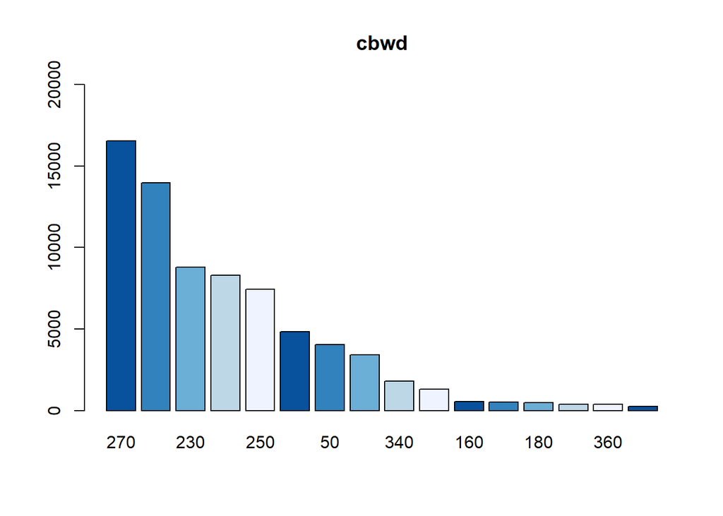

```r
library(RColorBrewer)

color.palette <- sort(RColorBrewer::brewer.pal(n = 5, name = "Blues"), decreasing = FALSE)
barplot(sort(table(PM.factor$cbwd), decreasing = TRUE), col = color.palette,
        main = "cbwd", ylim = c(0, 20000))
```

##### D. 양적자료의 분석

```r
Mean <- c()
trim.Mean <- c()
Median <- c()
Mode <- c()
Range <- c()
IQR.data <- c()
var.data <- c()
sd.data <- c()
mad.data <- c()
for(i in 1:ncol(PM.numeric)){
  Mean <- c(Mean, mean(PM.numeric[, i], na.rm = TRUE))
  trim.Mean <- c(trim.Mean, mean(PM.numeric[, i], trim = 0.05, na.rm = TRUE))
  Median <- c(Median, median(PM.numeric[, i], na.rm = TRUE))
  Mode <- c(Mode, prettyR::Mode(PM.numeric[, i], na.rm = TRUE))
  Range <- c(Range, diff(range(PM.numeric[, i], na.rm = TRUE)))
  IQR.data <- c(IQR.data, IQR(PM.numeric[, i], na.rm = TRUE))
  var.data <- c(var.data, var(PM.numeric[, i], na.rm = TRUE))
  sd.data <- c(sd.data, sd(PM.numeric[, i], na.rm = TRUE))
  mad.data <- c(mad.data, mad(PM.numeric[, i], na.rm = TRUE))
}
result <- data.frame(Variable = colnames(PM.numeric), Mean, trim.Mean, Median, Mode, Range,
                     IQR = IQR.data, var = var.data, sd = sd.data, mad = mad.data)
result
```

```
##    Variable         Mean    trim.Mean   Median    Mode     Range      IQR
## 1      year 2.013500e+03 2.013500e+03 2013.500 >1 mode     7.000    4.000
## 2     month 6.522930e+00 6.525477e+00    7.000 >1 mode    11.000    6.000
## 3       day 1.572964e+01 1.571560e+01   16.000 >1 mode    30.000   15.000
## 4       SO2 5.166137e-03 5.051297e-03    0.005   0.005     0.032    0.002
## 5        CO 5.303948e-01 5.141629e-01    0.500     0.4     2.700    0.200
## 6        O3 2.201626e-02 2.141267e-02    0.020   0.014     0.093    0.018
## 7       NO2 3.207454e-02 3.144064e-02    0.030   0.024     0.110    0.018
## 8      PM10 4.554028e+01 4.296526e+01   40.000      30   706.000   28.000
## 9      temp 1.284298e+01 1.310635e+01   14.400    24.7    46.300   19.700
## 10     prec 9.471737e+00 5.551031e+00    1.500       0   301.500    7.400
## 11       ws 2.578383e+00 2.518749e+00    2.400     2.2     6.600    1.000
## 12     humi 5.985886e+01 5.974806e+01   59.600    60.4    79.700   21.700
## 13     pres 1.005974e+03 1.006008e+03 1006.200  1007.6    45.800   12.400
## 14    kospi 1.990338e+03 1.983097e+03 1982.200 >1 mode  1005.180  130.860
```

[output cut: 25 more lines]

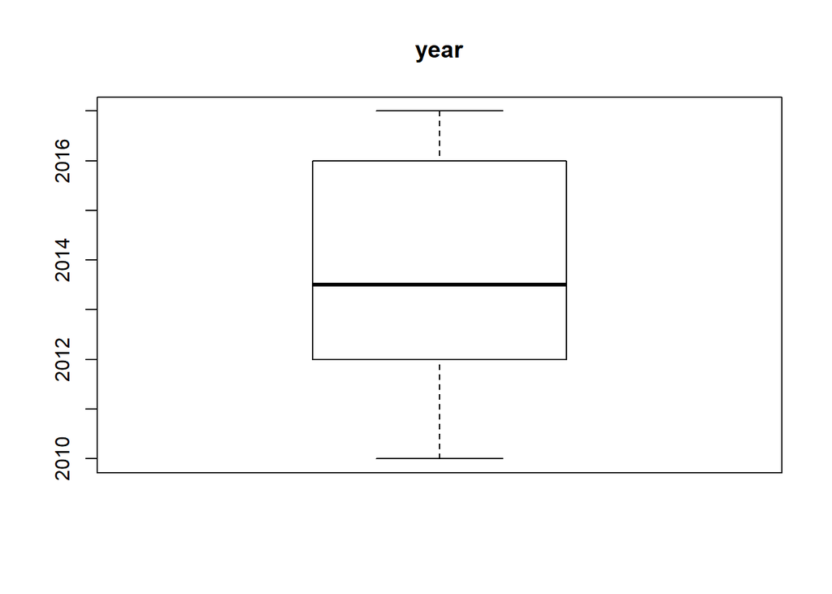

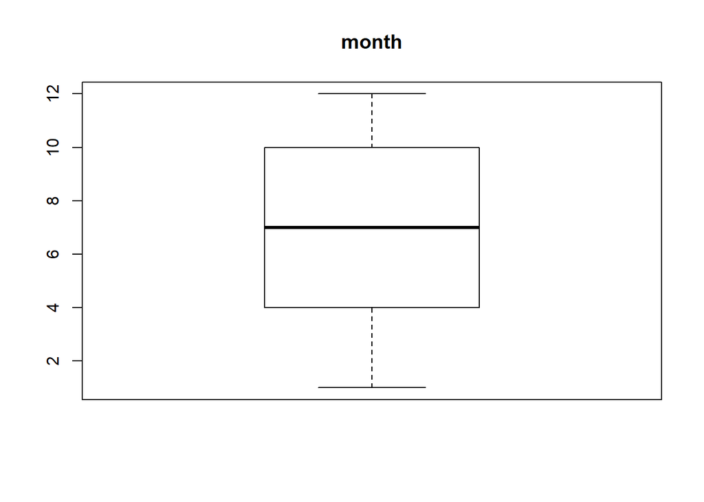

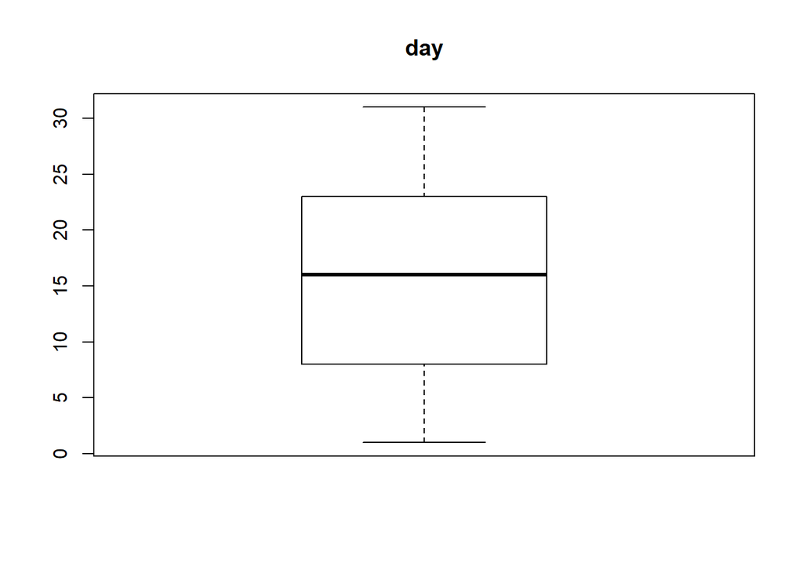

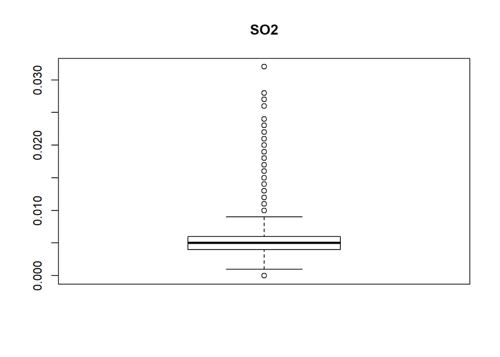

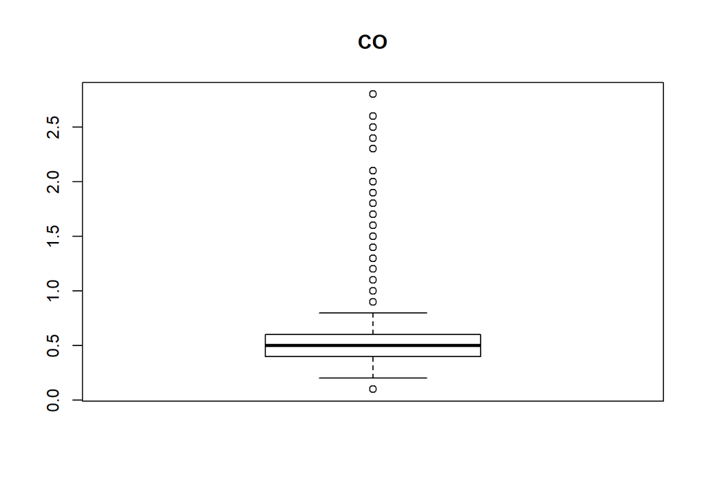

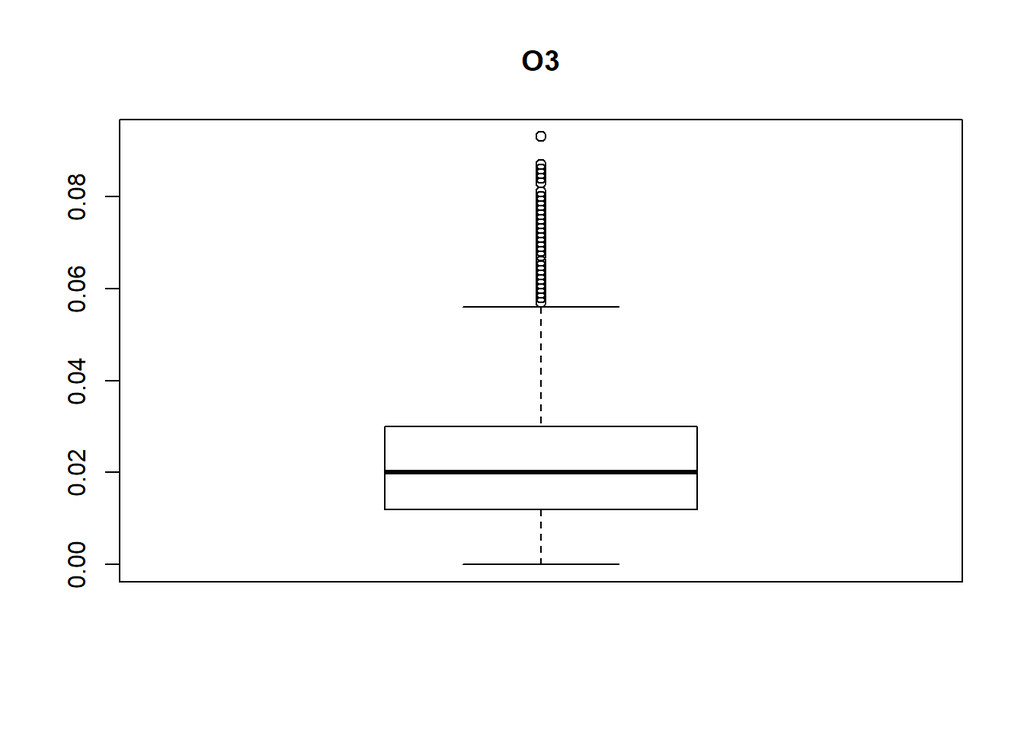

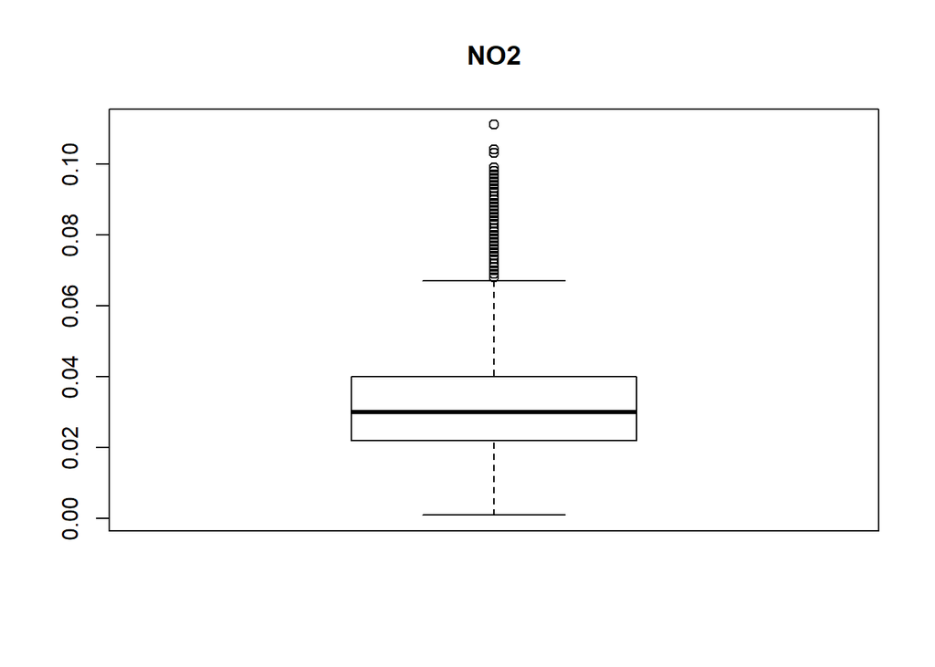

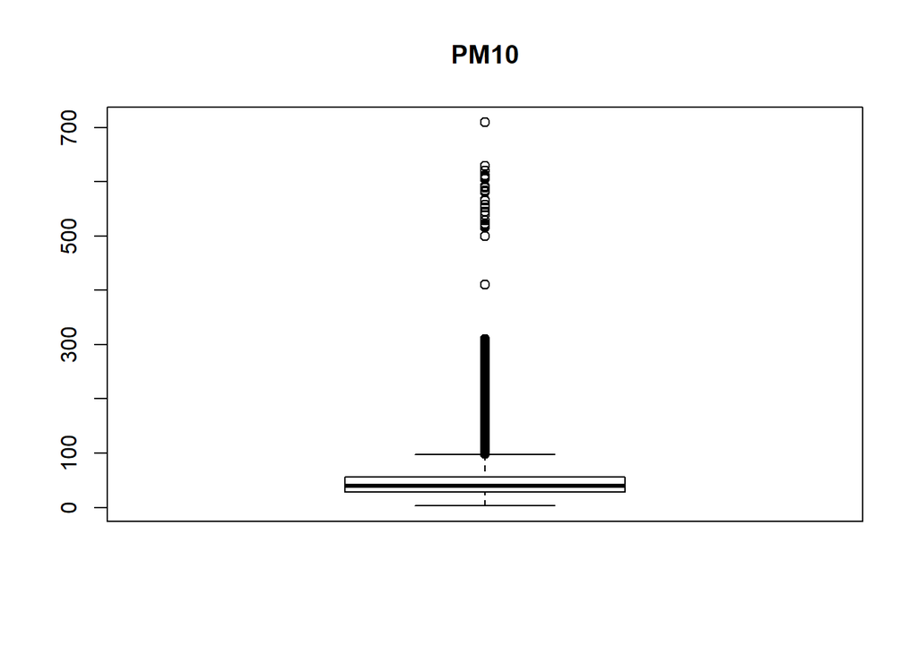

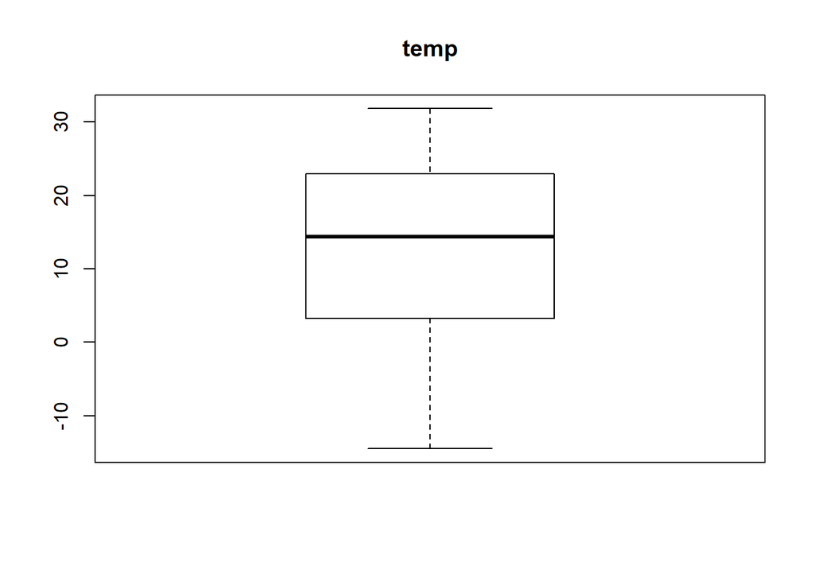

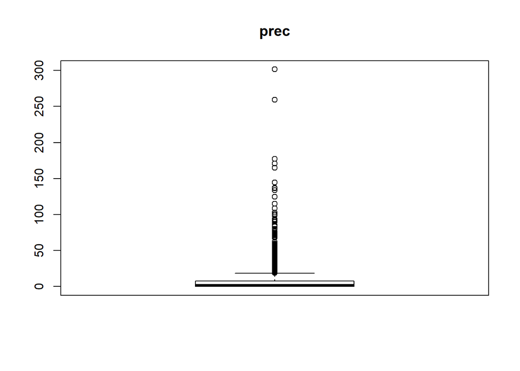

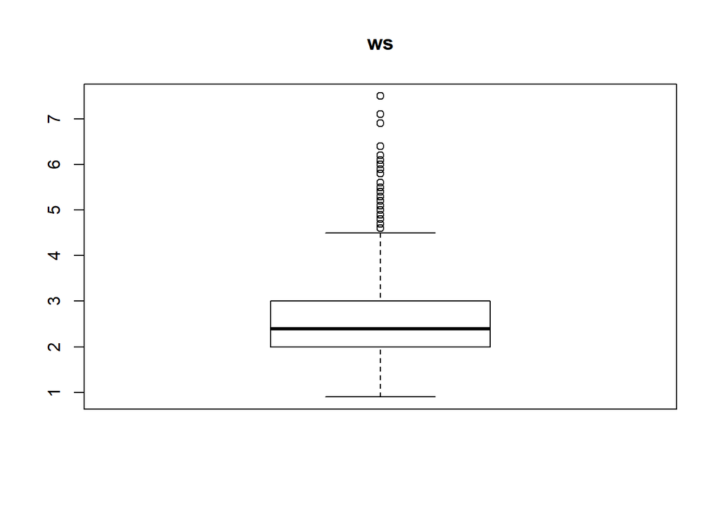

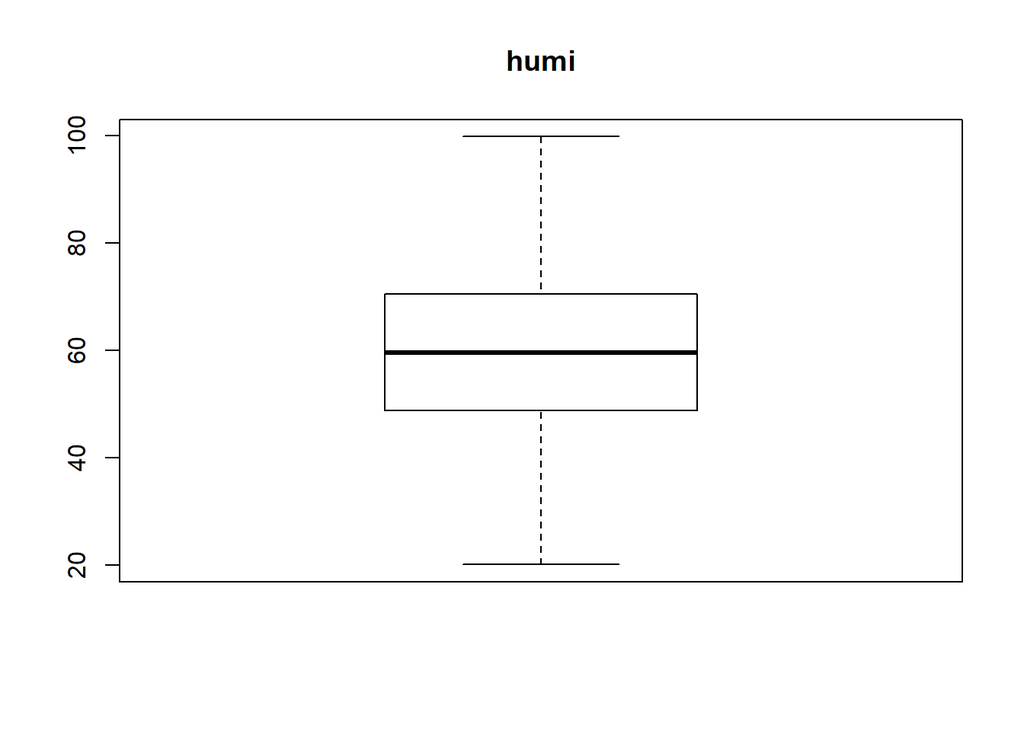

[7 more figures not shown]

```r
for(i in 1:(ncol(PM.numeric))){
  boxplot(PM.numeric[, i], main = colnames(PM.numeric)[i])
}
```

#### **ii) NA값 처리**

##### A. SO2, CO, O3, NO2, PM10

대기오염물질은 에어코리아에서 이상치가 측정되었을 때 -999로 표기한다고 알려주었다. 이를 NA로 바꿔준다.

```r
PM$SO2 <- ifelse(PM$SO2 < 0, NA, PM$SO2)
PM$CO <- ifelse(PM$CO < 0, NA, PM$CO)
PM$O3 <- ifelse(PM$O3 < 0, NA, PM$O3)
PM$NO2 <- ifelse(PM$NO2 < 0, NA, PM$NO2)
PM$PM10 <- ifelse(PM$PM10 < 0, NA, PM$PM10)
```

##### B. kospi 이외의 NA값이 있는 변수들

boxplot을 봤을때 평균을 넣는다면 이상치가 들어가기 때문에 중위수를 넣는다.

```r
PM[is.na(PM$SO2), 'SO2'] <- median(PM$SO2, na.rm = TRUE)
PM[is.na(PM$CO), 'CO'] <- median(PM$CO, na.rm = TRUE)
PM[is.na(PM$O3), 'O3'] <- median(PM$O3, na.rm = TRUE)
PM[is.na(PM$NO2), 'NO2'] <- median(PM$NO2, na.rm = TRUE)
PM[is.na(PM$ws), 'ws'] <- median(PM$ws, na.rm = TRUE)
PM[is.na(PM$pres), 'pres'] <- mean(PM$pres, na.rm = TRUE)
PM[is.na(PM$cbwd), 'cbwd'] <- prettyR::Mode(PM$cbwd, na.rm = TRUE)
PM$cbwd <- as.factor(PM$cbwd)

PM[is.na(PM$PM10), 'PM10'] <- median(PM$PM10, na.rm = TRUE)
```

##### C. prec

prec는 기상청에 QnA에 올라온 자료를 보면, 센서의 최소 측정 수준이 0.1mm이기 때문에 그 이하는 0으로 표시되어 있으며 강수가 없는날에는 측정하지 않기 때문에 NA로 측정되어 있다고 한다.

```r
PM$prec <- ifelse(PM$prec == 0, 0.1, PM$prec)
PM[is.na(PM$prec), 'prec'] <- 0
```

##### D. kospi

kospi는 NA값이 너무 많아서 전부 평균이나 중위수로 넣는다면 한 데이터 값만 너무 많은 개수를 가지게 된다.  
그래서 kospi를 타겟변수로 하는 회귀분석을 돌려서 회귀식을 만든 후 kospi값을 예측하여 예측값으로 NA를 대체한다.

```r
summary(PM$kospi)
```

```
##    Min. 1st Qu.  Median    Mean 3rd Qu.    Max.    NA's
##    1553    1913    1982    1990    2044    2558   23650
```

```r
PM.kospi <- PM[complete.cases(PM$kospi), ]
PM.kospi.model <- lm(kospi ~ ., data = PM.kospi)

PM.kospi.na <- PM[!complete.cases(PM$kospi), ]
PM[is.na(PM$kospi), 'kospi'] <- predict(PM.kospi.model, PM.kospi.na)
summary(PM$kospi)
```

```
##    Min. 1st Qu.  Median    Mean 3rd Qu.    Max.
##    1553    1912    1982    1992    2056    2558
```

##### E. month, day

month와 day는 반복되는 변수기 때문에 순환형 변수로 만들어 준다.

```r
PM$month.x <- sin((360 / 12) * PM$month)
PM$month.y <- cos((360 / 12) * PM$month)
day.x <- c()
day.y <- c()
for(i in 1:73050){
  if(PM$year[i] %in% c(2012, 2016)){
    if(PM$month[i] %in% c(1, 3, 5, 7, 8, 10, 12)){
      day.date <- 31
    } else if(PM$month[i] == 2){
      day.date <- 29
    } else {
      day.date <- 30
    }
  } else {
    if(PM$month[i] %in% c(1, 3, 5, 7, 8, 10, 12)){
      day.date <- 31
    } else if(PM$month[i] == 2){
      day.date <- 28
    } else {
      day.date <- 30
    }
  }
  day.x <- c(day.x, sin((360 / day.date) * PM$day[i]))
  day.y <- c(day.y, cos((360 / day.date) * PM$day[i]))
}
PM$day.x <- day.x
PM$day.y <- day.y
PM$month <- NULL
PM$day <- NULL
```

### **3. 회귀분석**

#### **i) 데이터 나누기**

2010년 ~ 2015년의 데이터를 이용하여 2016년 ~ 2017년의 미세먼지를 예측할 수 있는지를 알아보기 위해  
2010년 ~ 2015년 데이터를 train데이터로, 2016년 ~ 2017년 데이터를 test데이터로 사용한다.

```r
PM.train <- PM %>%
  dplyr::filter(year <= 2015)
PM.test <- PM %>%
  dplyr::filter(year > 2015)
head(PM.train$year)
```

```
## [1] 2010 2010 2010 2010 2010 2010
```

```r
tail(PM.train$year)
```

```
## [1] 2015 2015 2015 2015 2015 2015
```

```r
head(PM.test$year)
```

```
## [1] 2016 2016 2016 2016 2016 2016
```

```r
tail(PM.test$year)
```

```
## [1] 2017 2017 2017 2017 2017 2017
```

#### **ii) 1차 회귀분석**

```r
PM.model <- lm(PM10 ~ ., data = PM.train)
summary(PM.model)
```

```
##
## Call:
## lm(formula = PM10 ~ ., data = PM.train)
##
## Residuals:
##     Min      1Q  Median      3Q     Max
## -122.34  -10.74   -3.06    5.94  679.39
##
## Coefficients:
##                    Estimate Std. Error t value Pr(>|t|)
## (Intercept)       1.892e+03  2.117e+02   8.935  < 2e-16 ***
## location강동구   -2.416e+00  7.031e-01  -3.436 0.000590 ***
## location강북구   -1.009e+00  7.037e-01  -1.433 0.151773
## location강서구   -5.521e+00  6.927e-01  -7.971 1.61e-15 ***
## location관악구   -1.727e+00  7.123e-01  -2.424 0.015333 *
## location광진구   -3.910e-01  7.067e-01  -0.553 0.580104
## location구로구   -3.016e+00  7.060e-01  -4.272 1.94e-05 ***
## location금천구   -6.367e+00  7.056e-01  -9.024  < 2e-16 ***
## location노원구   -3.556e+00  7.067e-01  -5.031 4.89e-07 ***
## location도봉구   -3.781e+00  7.161e-01  -5.279 1.30e-07 ***
## location동대문구 -4.769e+00  7.012e-01  -6.802 1.04e-11 ***
## location동작구   -8.058e+00  7.064e-01 -11.407  < 2e-16 ***
## location마포구    4.405e-01  7.077e-01   0.622 0.533649
## location서대문구 -5.217e-01  7.064e-01  -0.738 0.460249
## location서초구   -4.656e-01  6.944e-01  -0.670 0.502579
## location성동구    7.499e+00  6.991e-01  10.728  < 2e-16 ***
## location성북구   -6.674e+00  7.053e-01  -9.463  < 2e-16 ***
## location송파구   -4.776e+00  8.289e-01  -5.762 8.35e-09 ***
## location양천구   -3.430e+00  6.948e-01  -4.936 8.00e-07 ***
## location영등포구 -5.284e+00  7.029e-01  -7.517 5.70e-14 ***
## location용산구   -1.457e+00  6.917e-01  -2.107 0.035161 *
## location은평구   -2.816e+00  7.076e-01  -3.979 6.92e-05 ***
## location종로구   -1.580e+00  7.143e-01  -2.212 0.027001 *
## location중구     -4.760e+00  6.971e-01  -6.828 8.69e-12 ***
## location중랑구    1.290e+00  7.032e-01   1.835 0.066497 .
## year             -9.084e-01  1.057e-01  -8.595  < 2e-16 ***
## SO2               3.102e+03  6.204e+01  50.007  < 2e-16 ***
## CO                4.033e+01  6.797e-01  59.333  < 2e-16 ***
## O3                5.758e+02  1.190e+01  48.394  < 2e-16 ***
## NO2               5.524e+02  1.229e+01  44.961  < 2e-16 ***
```

[output cut: 21 more lines]

```
## gasoline         -1.468e-02  2.873e-03  -5.111 3.22e-07 ***
## kerosene         -4.484e-02  4.081e-03 -10.987  < 2e-16 ***
## bunker           -1.208e-02  7.667e-04 -15.759  < 2e-16 ***
## LPG               2.420e-02  2.197e-03  11.014  < 2e-16 ***
## oil               4.867e-05  2.497e-05   1.949 0.051271 .
## month.x           7.967e-01  1.596e-01   4.991 6.01e-07 ***
## month.y          -7.354e-01  1.526e-01  -4.820 1.44e-06 ***
## day.x            -3.033e-01  1.365e-01  -2.222 0.026271 *
## day.y             1.611e+00  1.400e-01  11.504  < 2e-16 ***
## ---
## Signif. codes:  0 '***' 0.001 '**' 0.01 '*' 0.05 '.' 0.1 ' ' 1
##
## Residual standard error: 22.67 on 54715 degrees of freedom
## Multiple R-squared:  0.414,  Adjusted R-squared:  0.4133
## F-statistic: 655.1 on 59 and 54715 DF,  p-value: < 2.2e-16
```

회귀식을 얻었으니, 이를 활용하여 타겟변수의 값을 예측하고, 실제값과 비교하여 RMSE값을 계산한다.

```r
predict.data <- predict(PM.model, PM.test)
PM.test$predict <- predict.data
PM.test$Error <- (PM.test$PM10 - PM.test$predict) ** 2
sqrt(mean(PM.test$Error))
```

```
## [1] 19.3696
```

#### **iii) RMSE값 낮추기**

미세먼지는 이전 날짜의 미세먼지의 농도에 영향을 받는다.

```r
ago1 <- c(0, PM$PM10[1:73049])
ago2 <- c(0, ago1[1:73049])
ago3 <- c(0, ago2[1:73049])
ago4 <- c(0, ago3[1:73049])
ago5 <- c(0, ago4[1:73049])
ago6 <- c(0, ago5[1:73049])

PM$PM10ago1 <- ago1
PM$PM10ago2 <- ago2
PM$PM10ago3 <- ago3
PM$PM10ago4 <- ago4
PM$PM10ago5 <- ago5
PM$PM10ago6 <- ago6
```

#### **iv) 2차 회귀분석**

1차와 동일한 방법으로 회귀분석을 실시한다.  
이 때 새로운 변수를 train과 test가 합쳐져있는 PM에 넣었으니, 다시 train과 test를 나눠준다.

```r
PM.train <- PM %>%
  dplyr::filter(year <= 2015)
PM.test <- PM %>%
  dplyr::filter(year > 2015)

PM.model <- lm(PM10 ~ ., data = PM.train)
summary(PM.model)
```

```
##
## Call:
## lm(formula = PM10 ~ ., data = PM.train)
##
## Residuals:
##     Min      1Q  Median      3Q     Max
## -200.37   -8.55   -1.62    5.83  549.86
##
## Coefficients:
##                    Estimate Std. Error t value Pr(>|t|)
## (Intercept)       1.243e+03  1.838e+02   6.759 1.40e-11 ***
## location강동구   -1.476e+00  6.099e-01  -2.421 0.015501 *
## location강북구   -2.573e-01  6.105e-01  -0.421 0.673464
## location강서구   -4.244e+00  6.010e-01  -7.062 1.67e-12 ***
## location관악구   -1.506e+00  6.180e-01  -2.438 0.014790 *
## location광진구   -2.160e-01  6.131e-01  -0.352 0.724638
## location구로구   -2.323e+00  6.124e-01  -3.794 0.000149 ***
## location금천구   -4.578e+00  6.122e-01  -7.477 7.71e-14 ***
## location노원구   -2.220e+00  6.132e-01  -3.621 0.000294 ***
## location도봉구   -2.211e+00  6.213e-01  -3.558 0.000374 ***
## location동대문구 -3.477e+00  6.083e-01  -5.716 1.10e-08 ***
## location동작구   -5.535e+00  6.131e-01  -9.028  < 2e-16 ***
## location마포구    4.576e-02  6.140e-01   0.075 0.940586
## location서대문구 -2.144e-02  6.128e-01  -0.035 0.972087
## location서초구   -4.770e-01  6.024e-01  -0.792 0.428454
## location성동구    5.420e+00  6.066e-01   8.936  < 2e-16 ***
## location성북구   -4.094e+00  6.122e-01  -6.688 2.29e-11 ***
## location송파구   -3.181e+00  7.191e-01  -4.424 9.70e-06 ***
## location양천구   -2.483e+00  6.027e-01  -4.119 3.81e-05 ***
## location영등포구 -4.157e+00  6.099e-01  -6.817 9.40e-12 ***
## location용산구   -8.308e-01  6.000e-01  -1.385 0.166157
## location은평구   -1.848e+00  6.138e-01  -3.011 0.002604 **
## location종로구   -1.281e+00  6.196e-01  -2.067 0.038739 *
## location중구     -3.197e+00  6.048e-01  -5.286 1.25e-07 ***
## location중랑구    8.690e-01  6.100e-01   1.425 0.154261
## year             -6.711e-01  9.172e-02  -7.317 2.57e-13 ***
## SO2               2.433e+03  5.406e+01  45.002  < 2e-16 ***
## CO                2.996e+01  5.961e-01  50.258  < 2e-16 ***
## O3                3.506e+02  1.048e+01  33.471  < 2e-16 ***
## NO2               3.469e+02  1.083e+01  32.033  < 2e-16 ***
```

[output cut: 27 more lines]

```
## month.y          -4.908e-01  1.324e-01  -3.708 0.000209 ***
## day.x            -1.816e-01  1.188e-01  -1.528 0.126437
## day.y             1.509e+00  1.216e-01  12.409  < 2e-16 ***
## PM10ago1          4.776e-01  3.834e-03 124.584  < 2e-16 ***
## PM10ago2         -1.228e-01  4.313e-03 -28.466  < 2e-16 ***
## PM10ago3          2.831e-02  4.347e-03   6.513 7.45e-11 ***
## PM10ago4          2.348e-02  4.346e-03   5.401 6.65e-08 ***
## PM10ago5         -7.754e-03  4.315e-03  -1.797 0.072342 .
## PM10ago6          1.849e-02  3.652e-03   5.062 4.16e-07 ***
## ---
## Signif. codes:  0 '***' 0.001 '**' 0.01 '*' 0.05 '.' 0.1 ' ' 1
##
## Residual standard error: 19.67 on 54709 degrees of freedom
## Multiple R-squared:  0.5591, Adjusted R-squared:  0.5586
## F-statistic:  1067 on 65 and 54709 DF,  p-value: < 2.2e-16
```

```r
PM.stepwise.model <- step(PM.model, direction = 'both')
```

```
## Start:  AIC=326398.4
## PM10 ~ location + year + SO2 + CO + O3 + NO2 + temp + prec +
##     cbwd + ws + humi + pres + kospi + gasoline + kerosene + bunker +
##     LPG + oil + month.x + month.y + day.x + day.y + PM10ago1 +
##     PM10ago2 + PM10ago3 + PM10ago4 + PM10ago5 + PM10ago6
##
##            Df Sum of Sq      RSS    AIC
## - kospi     1       110 21156927 326397
## <none>                  21156817 326398
## - day.x     1       903 21157720 326399
## - temp      1       968 21157785 326399
## - oil       1      1168 21157985 326399
## - PM10ago5  1      1249 21158066 326400
## - gasoline  1      2392 21159209 326403
## - pres      1      4133 21160950 326407
## - month.y   1      5318 21162135 326410
## - month.x   1      9069 21165886 326420
## - PM10ago6  1      9910 21166727 326422
## - PM10ago4  1     11281 21168098 326426
## - PM10ago3  1     16402 21173219 326439
## - year      1     20703 21177520 326450
## - LPG       1     30862 21187679 326476
## - humi      1     38342 21195159 326496
## - kerosene  1     47362 21204179 326519
## - bunker    1     48533 21205350 326522
## - day.y     1     59552 21216369 326550
## - ws        1     75559 21232376 326592
## - prec      1    215999 21372816 326953
## - location 24    253718 21410535 327003
## - PM10ago2  1    313352 21470169 327202
## - NO2       1    396816 21553633 327414
## - O3        1    433249 21590066 327507
## - cbwd     15    573586 21730403 327834
## - SO2       1    783159 21939976 328387
## - CO        1    976806 22133624 328869
## - PM10ago1  1   6002257 27159074 340076
##
## Step:  AIC=326396.7
## PM10 ~ location + year + SO2 + CO + O3 + NO2 + temp + prec +
##     cbwd + ws + humi + pres + gasoline + kerosene + bunker +
```

[output cut: 18 more lines]

```
## - LPG       1     32666 21189593 326479
## - humi      1     38605 21195532 326495
## - kerosene  1     47328 21204255 326517
## - bunker    1     48453 21205380 326520
## - day.y     1     59549 21216476 326549
## - ws        1     75641 21232568 326590
## - prec      1    218463 21375390 326957
## - location 24    253640 21410567 327001
## - PM10ago2  1    313404 21470331 327200
## - NO2       1    397185 21554112 327413
## - O3        1    433410 21590337 327505
## - cbwd     15    575125 21732052 327836
## - SO2       1    783739 21940666 328387
## - CO        1    976863 22133790 328867
## - PM10ago1  1   6004448 27161375 340079
```

```r
summary(PM.stepwise.model)
```

```
##
## Call:
## lm(formula = PM10 ~ location + year + SO2 + CO + O3 + NO2 + temp +
##     prec + cbwd + ws + humi + pres + gasoline + kerosene + bunker +
##     LPG + oil + month.x + month.y + day.x + day.y + PM10ago1 +
##     PM10ago2 + PM10ago3 + PM10ago4 + PM10ago5 + PM10ago6, data = PM.train)
##
## Residuals:
##     Min      1Q  Median      3Q     Max
## -200.43   -8.56   -1.62    5.84  549.81
##
## Coefficients:
##                    Estimate Std. Error t value Pr(>|t|)
## (Intercept)       1.189e+03  1.544e+02   7.702 1.37e-14 ***
## location강동구   -1.477e+00  6.099e-01  -2.421 0.015477 *
## location강북구   -2.575e-01  6.105e-01  -0.422 0.673245
## location강서구   -4.241e+00  6.009e-01  -7.058 1.71e-12 ***
## location관악구   -1.507e+00  6.180e-01  -2.439 0.014717 *
## location광진구   -2.161e-01  6.131e-01  -0.353 0.724446
## location구로구   -2.323e+00  6.124e-01  -3.793 0.000149 ***
## location금천구   -4.578e+00  6.122e-01  -7.477 7.73e-14 ***
## location노원구   -2.220e+00  6.132e-01  -3.620 0.000295 ***
## location도봉구   -2.210e+00  6.213e-01  -3.558 0.000374 ***
## location동대문구 -3.477e+00  6.083e-01  -5.717 1.09e-08 ***
## location동작구   -5.534e+00  6.131e-01  -9.026  < 2e-16 ***
## location마포구    4.453e-02  6.140e-01   0.073 0.942179
## location서대문구 -2.213e-02  6.128e-01  -0.036 0.971196
## location서초구   -4.765e-01  6.024e-01  -0.791 0.428876
## location성동구    5.419e+00  6.066e-01   8.933  < 2e-16 ***
## location성북구   -4.095e+00  6.122e-01  -6.690 2.25e-11 ***
## location송파구   -3.177e+00  7.190e-01  -4.418 9.99e-06 ***
## location양천구   -2.482e+00  6.027e-01  -4.118 3.82e-05 ***
## location영등포구 -4.157e+00  6.099e-01  -6.816 9.45e-12 ***
## location용산구   -8.317e-01  6.000e-01  -1.386 0.165705
## location은평구   -1.848e+00  6.138e-01  -3.012 0.002601 **
## location종로구   -1.280e+00  6.196e-01  -2.066 0.038798 *
## location중구     -3.198e+00  6.048e-01  -5.287 1.25e-07 ***
## location중랑구    8.687e-01  6.100e-01   1.424 0.154392
## year             -6.437e-01  7.603e-02  -8.467  < 2e-16 ***
## SO2               2.432e+03  5.402e+01  45.019  < 2e-16 ***
```

[output cut: 29 more lines]

```
## month.y          -4.878e-01  1.322e-01  -3.689 0.000225 ***
## day.x            -1.824e-01  1.188e-01  -1.535 0.124723
## day.y             1.509e+00  1.216e-01  12.409  < 2e-16 ***
## PM10ago1          4.776e-01  3.833e-03 124.607  < 2e-16 ***
## PM10ago2         -1.228e-01  4.313e-03 -28.468  < 2e-16 ***
## PM10ago3          2.830e-02  4.347e-03   6.511 7.54e-11 ***
## PM10ago4          2.348e-02  4.346e-03   5.401 6.65e-08 ***
## PM10ago5         -7.741e-03  4.315e-03  -1.794 0.072835 .
## PM10ago6          1.847e-02  3.652e-03   5.058 4.26e-07 ***
## ---
## Signif. codes:  0 '***' 0.001 '**' 0.01 '*' 0.05 '.' 0.1 ' ' 1
##
## Residual standard error: 19.66 on 54710 degrees of freedom
## Multiple R-squared:  0.5591, Adjusted R-squared:  0.5586
## F-statistic:  1084 on 64 and 54710 DF,  p-value: < 2.2e-16
```

```r
predict.data <- predict(PM.model, PM.test)
PM.test$predict <- predict.data
PM.test$Error <- (PM.test$PM10 - PM.test$predict) ** 2
RMSE <- sqrt(mean(PM.test$Error))
RMSE
```

```
## [1] 16.33283
```

```r
Mean <- mean(PM.test$PM10)
Mean
```

```
## [1] 45.73997
```

```r
predict.rate <- round((1 - (RMSE / Mean)) * 100, digits = 1)
paste0(predict.rate, '%')
```

```
## [1] "64.3%"
```

```r
PM.normal <- PM
for(i in 1:ncol(PM.normal)){
  if(is.numeric(PM.normal[i])){
    PM.normal[, i] <- scale(PM.normal[, i])
  }
}
```

```r
PM.normal.train <- PM.normal %>%
  dplyr::filter(year <= 2015)
PM.normal.test <- PM.normal %>%
  dplyr::filter(year > 2015)

PM.normal.model <- lm(PM10 ~ ., data = PM.normal.train)
summary(PM.normal.model)
```

```
##
## Call:
## lm(formula = PM10 ~ ., data = PM.normal.train)
##
## Residuals:
##     Min      1Q  Median      3Q     Max
## -200.37   -8.55   -1.62    5.83  549.86
##
## Coefficients:
##                    Estimate Std. Error t value Pr(>|t|)
## (Intercept)       1.243e+03  1.838e+02   6.759 1.40e-11 ***
## location강동구   -1.476e+00  6.099e-01  -2.421 0.015501 *
## location강북구   -2.573e-01  6.105e-01  -0.421 0.673464
## location강서구   -4.244e+00  6.010e-01  -7.062 1.67e-12 ***
## location관악구   -1.506e+00  6.180e-01  -2.438 0.014790 *
## location광진구   -2.160e-01  6.131e-01  -0.352 0.724638
## location구로구   -2.323e+00  6.124e-01  -3.794 0.000149 ***
## location금천구   -4.578e+00  6.122e-01  -7.477 7.71e-14 ***
## location노원구   -2.220e+00  6.132e-01  -3.621 0.000294 ***
## location도봉구   -2.211e+00  6.213e-01  -3.558 0.000374 ***
## location동대문구 -3.477e+00  6.083e-01  -5.716 1.10e-08 ***
## location동작구   -5.535e+00  6.131e-01  -9.028  < 2e-16 ***
## location마포구    4.576e-02  6.140e-01   0.075 0.940586
## location서대문구 -2.144e-02  6.128e-01  -0.035 0.972087
## location서초구   -4.770e-01  6.024e-01  -0.792 0.428454
## location성동구    5.420e+00  6.066e-01   8.936  < 2e-16 ***
## location성북구   -4.094e+00  6.122e-01  -6.688 2.29e-11 ***
## location송파구   -3.181e+00  7.191e-01  -4.424 9.70e-06 ***
## location양천구   -2.483e+00  6.027e-01  -4.119 3.81e-05 ***
## location영등포구 -4.157e+00  6.099e-01  -6.817 9.40e-12 ***
## location용산구   -8.308e-01  6.000e-01  -1.385 0.166157
## location은평구   -1.848e+00  6.138e-01  -3.011 0.002604 **
## location종로구   -1.281e+00  6.196e-01  -2.067 0.038739 *
## location중구     -3.197e+00  6.048e-01  -5.286 1.25e-07 ***
## location중랑구    8.690e-01  6.100e-01   1.425 0.154261
## year             -6.711e-01  9.172e-02  -7.317 2.57e-13 ***
## SO2               2.433e+03  5.406e+01  45.002  < 2e-16 ***
## CO                2.996e+01  5.961e-01  50.258  < 2e-16 ***
## O3                3.506e+02  1.048e+01  33.471  < 2e-16 ***
## NO2               3.469e+02  1.083e+01  32.033  < 2e-16 ***
```

[output cut: 27 more lines]

```
## month.y          -4.908e-01  1.324e-01  -3.708 0.000209 ***
## day.x            -1.816e-01  1.188e-01  -1.528 0.126437
## day.y             1.509e+00  1.216e-01  12.409  < 2e-16 ***
## PM10ago1          4.776e-01  3.834e-03 124.584  < 2e-16 ***
## PM10ago2         -1.228e-01  4.313e-03 -28.466  < 2e-16 ***
## PM10ago3          2.831e-02  4.347e-03   6.513 7.45e-11 ***
## PM10ago4          2.348e-02  4.346e-03   5.401 6.65e-08 ***
## PM10ago5         -7.754e-03  4.315e-03  -1.797 0.072342 .
## PM10ago6          1.849e-02  3.652e-03   5.062 4.16e-07 ***
## ---
## Signif. codes:  0 '***' 0.001 '**' 0.01 '*' 0.05 '.' 0.1 ' ' 1
##
## Residual standard error: 19.67 on 54709 degrees of freedom
## Multiple R-squared:  0.5591, Adjusted R-squared:  0.5586
## F-statistic:  1067 on 65 and 54709 DF,  p-value: < 2.2e-16
```

```r
PM.normal.stepwise.model <- step(PM.normal.model, direction = 'both')
```

```
## Start:  AIC=326398.4
## PM10 ~ location + year + SO2 + CO + O3 + NO2 + temp + prec +
##     cbwd + ws + humi + pres + kospi + gasoline + kerosene + bunker +
##     LPG + oil + month.x + month.y + day.x + day.y + PM10ago1 +
##     PM10ago2 + PM10ago3 + PM10ago4 + PM10ago5 + PM10ago6
##
##            Df Sum of Sq      RSS    AIC
## - kospi     1       110 21156927 326397
## <none>                  21156817 326398
## - day.x     1       903 21157720 326399
## - temp      1       968 21157785 326399
## - oil       1      1168 21157985 326399
## - PM10ago5  1      1249 21158066 326400
## - gasoline  1      2392 21159209 326403
## - pres      1      4133 21160950 326407
## - month.y   1      5318 21162135 326410
## - month.x   1      9069 21165886 326420
## - PM10ago6  1      9910 21166727 326422
## - PM10ago4  1     11281 21168098 326426
## - PM10ago3  1     16402 21173219 326439
## - year      1     20703 21177520 326450
## - LPG       1     30862 21187679 326476
## - humi      1     38342 21195159 326496
## - kerosene  1     47362 21204179 326519
## - bunker    1     48533 21205350 326522
## - day.y     1     59552 21216369 326550
## - ws        1     75559 21232376 326592
## - prec      1    215999 21372816 326953
## - location 24    253718 21410535 327003
## - PM10ago2  1    313352 21470169 327202
## - NO2       1    396816 21553633 327414
## - O3        1    433249 21590066 327507
## - cbwd     15    573586 21730403 327834
## - SO2       1    783159 21939976 328387
## - CO        1    976806 22133624 328869
## - PM10ago1  1   6002257 27159074 340076
##
## Step:  AIC=326396.7
## PM10 ~ location + year + SO2 + CO + O3 + NO2 + temp + prec +
##     cbwd + ws + humi + pres + gasoline + kerosene + bunker +
```

[output cut: 18 more lines]

```
## - LPG       1     32666 21189593 326479
## - humi      1     38605 21195532 326495
## - kerosene  1     47328 21204255 326517
## - bunker    1     48453 21205380 326520
## - day.y     1     59549 21216476 326549
## - ws        1     75641 21232568 326590
## - prec      1    218463 21375390 326957
## - location 24    253640 21410567 327001
## - PM10ago2  1    313404 21470331 327200
## - NO2       1    397185 21554112 327413
## - O3        1    433410 21590337 327505
## - cbwd     15    575125 21732052 327836
## - SO2       1    783739 21940666 328387
## - CO        1    976863 22133790 328867
## - PM10ago1  1   6004448 27161375 340079
```

```r
summary(PM.normal.stepwise.model)
```

```
##
## Call:
## lm(formula = PM10 ~ location + year + SO2 + CO + O3 + NO2 + temp +
##     prec + cbwd + ws + humi + pres + gasoline + kerosene + bunker +
##     LPG + oil + month.x + month.y + day.x + day.y + PM10ago1 +
##     PM10ago2 + PM10ago3 + PM10ago4 + PM10ago5 + PM10ago6, data = PM.normal.train)
##
## Residuals:
##     Min      1Q  Median      3Q     Max
## -200.43   -8.56   -1.62    5.84  549.81
##
## Coefficients:
##                    Estimate Std. Error t value Pr(>|t|)
## (Intercept)       1.189e+03  1.544e+02   7.702 1.37e-14 ***
## location강동구   -1.477e+00  6.099e-01  -2.421 0.015477 *
## location강북구   -2.575e-01  6.105e-01  -0.422 0.673245
## location강서구   -4.241e+00  6.009e-01  -7.058 1.71e-12 ***
## location관악구   -1.507e+00  6.180e-01  -2.439 0.014717 *
## location광진구   -2.161e-01  6.131e-01  -0.353 0.724446
## location구로구   -2.323e+00  6.124e-01  -3.793 0.000149 ***
## location금천구   -4.578e+00  6.122e-01  -7.477 7.73e-14 ***
## location노원구   -2.220e+00  6.132e-01  -3.620 0.000295 ***
## location도봉구   -2.210e+00  6.213e-01  -3.558 0.000374 ***
## location동대문구 -3.477e+00  6.083e-01  -5.717 1.09e-08 ***
## location동작구   -5.534e+00  6.131e-01  -9.026  < 2e-16 ***
## location마포구    4.453e-02  6.140e-01   0.073 0.942179
## location서대문구 -2.213e-02  6.128e-01  -0.036 0.971196
## location서초구   -4.765e-01  6.024e-01  -0.791 0.428876
## location성동구    5.419e+00  6.066e-01   8.933  < 2e-16 ***
## location성북구   -4.095e+00  6.122e-01  -6.690 2.25e-11 ***
## location송파구   -3.177e+00  7.190e-01  -4.418 9.99e-06 ***
## location양천구   -2.482e+00  6.027e-01  -4.118 3.82e-05 ***
## location영등포구 -4.157e+00  6.099e-01  -6.816 9.45e-12 ***
## location용산구   -8.317e-01  6.000e-01  -1.386 0.165705
## location은평구   -1.848e+00  6.138e-01  -3.012 0.002601 **
## location종로구   -1.280e+00  6.196e-01  -2.066 0.038798 *
## location중구     -3.198e+00  6.048e-01  -5.287 1.25e-07 ***
## location중랑구    8.687e-01  6.100e-01   1.424 0.154392
## year             -6.437e-01  7.603e-02  -8.467  < 2e-16 ***
## SO2               2.432e+03  5.402e+01  45.019  < 2e-16 ***
```

[output cut: 29 more lines]

```
## month.y          -4.878e-01  1.322e-01  -3.689 0.000225 ***
## day.x            -1.824e-01  1.188e-01  -1.535 0.124723
## day.y             1.509e+00  1.216e-01  12.409  < 2e-16 ***
## PM10ago1          4.776e-01  3.833e-03 124.607  < 2e-16 ***
## PM10ago2         -1.228e-01  4.313e-03 -28.468  < 2e-16 ***
## PM10ago3          2.830e-02  4.347e-03   6.511 7.54e-11 ***
## PM10ago4          2.348e-02  4.346e-03   5.401 6.65e-08 ***
## PM10ago5         -7.741e-03  4.315e-03  -1.794 0.072835 .
## PM10ago6          1.847e-02  3.652e-03   5.058 4.26e-07 ***
## ---
## Signif. codes:  0 '***' 0.001 '**' 0.01 '*' 0.05 '.' 0.1 ' ' 1
##
## Residual standard error: 19.66 on 54710 degrees of freedom
## Multiple R-squared:  0.5591, Adjusted R-squared:  0.5586
## F-statistic:  1084 on 64 and 54710 DF,  p-value: < 2.2e-16
```

```r
predict.data <- predict(PM.normal.model, PM.normal.test)
PM.normal.test$predict <- predict.data
PM.normal.test$Error <- (PM.normal.test$PM10 - PM.normal.test$predict) ** 2
RMSE <- sqrt(mean(PM.normal.test$Error))
RMSE
```

```
## [1] 16.33283
```

```r
Mean <- mean(PM.normal.test$PM10)
Mean
```

```
## [1] 45.73997
```

```r
predict.rate <- round((1 - (RMSE / Mean)) * 100, digits = 1)
paste0(predict.rate, '%')
```

```
## [1] "64.3%"
```